# Programando IA com R

# Portifólio R

*Realizado por Letticia Nicoli*

Esse markdown descreve, de forma breve, o que aprendi durante as aulas de “Programando IA com R” como ferramenta estatística e de modelagem de inteligência artificial.

## Criação de sequências e atribuição em variáveis

Apenas para testes simples, não use isso em produção! Coloque em uma variável :)

```r
1:5
```

```
## [1] 1 2 3 4 5
```

```r
50:20
```

```
##  [1] 50 49 48 47 46 45 44 43 42 41 40 39 38 37 36 35 34 33 32 31 30 29 28
## [24] 27 26 25 24 23 22 21 20
```

```r
6:-3
```

```
##  [1]  6  5  4  3  2  1  0 -1 -2 -3
```

```r
4:4
```

```
## [1] 4
```

```r
1:0
```

```
## [1] 1 0
```

```r
pi:6
```

```
## [1] 3.141593 4.141593 5.141593
```

Atribuindo um valor as varíaveis!

```r
a <- "1" -> b
c <- "2" -> d
e <- "3" -> f
g <- "4" -> h
i <- "5"
```

**Obs.:** Tá tudo bem, podemos utilizar `=` ao invés de `<-`

## Valores Especiais

Os valores especiais são `NA`, `NaN`, `Inf` e `-Inf`, `Null`

Exemplos:

```r
var_na = NA
var_nan = 0/0
var_inf = 9/0
var_inf_neg = -1/0
var_null = NULL
```

**NA vs NULL**

```r
c(18,NA,NA,19,50)
```

```
## [1] 18 NA NA 19 50
```

```r
c(18,NA,NULL,19,50)
```

```
## [1] 18 NA 19 50
```

Existem funções para validarmos se a variável é um valor especial:

```r
is.na(var_na)
```

```
## [1] TRUE
```

```r
is.nan(var_nan)
```

```
## [1] TRUE
```

```r
is.infinite(var_inf)
```

```
## [1] TRUE
```

```r
is.infinite(var_inf_neg)
```

```
## [1] TRUE
```

```r
is.finite(var_inf)
```

```
## [1] FALSE
```

```r
is.null(var_null)
```

```
## [1] TRUE
```

## Help

E antes de irmos mais a fundo…  
Se for precisar de ajudar utilize o comando `?` seguido do nome da função, operador, pacotes e etc que você tem dúvida.  
Conforme exemplo abaixo:

```r
?`:`
```

```r
?'is.infinite'
```

## Criação de diferentes tipos de vetores

**Vetor Inteiro**

```r
vetor_inteiro <- 11:13
vetor_inteiro
```

```
## [1] 11 12 13
```

**Vetor Numérico**

```r
vetor_numerico <- c(1.1,1.2,1.3)
vetor_numerico
```

```
## [1] 1.1 1.2 1.3
```

**Vetor Texto**

```r
vetor_texto <- letters[11:13]
vetor_texto
```

```
## [1] "k" "l" "m"
```

**Vetor Imaginário**

```r
vetor_imaginario <- c((1+1i), (1+2i),(1+1i))
vetor_imaginario
```

```
## [1] 1+1i 1+2i 1+1i
```

**Vetor Lógico**

```r
vetor_logico <- c(TRUE,FALSE,TRUE)
vetor_logico
```

```
## [1]  TRUE FALSE  TRUE
```

## Criação de listas

```r
list(vetor_inteiro,vetor_numerico,vetor_texto,vetor_imaginario,vetor_logico)
```

```
## [[1]]
## [1] 11 12 13
##
## [[2]]
## [1] 1.1 1.2 1.3
##
## [[3]]
## [1] "k" "l" "m"
##
## [[4]]
## [1] 1+1i 1+2i 1+1i
##
## [[5]]
## [1]  TRUE FALSE  TRUE
```

## Criação de sequências

No começo do markdown vimos que fazendo `{valor}:{valor}` conseguimos ter uma sequência de valores porém se você quer algo mais elaborado podemos utilizar a função **seq** para realizar ações como intervalo entre valores, quantidade total de valores dentro daquela sequência e etc.

```r
seq(0, 1, length.out = 11)
```

```
##  [1] 0.0 0.1 0.2 0.3 0.4 0.5 0.6 0.7 0.8 0.9 1.0
```

```r
seq(1, 9, by = 2)
```

```
## [1] 1 3 5 7 9
```

```r
seq(1, 6, by = 3)
```

```
## [1] 1 4
```

```r
seq_len(17)
```

```
##  [1]  1  2  3  4  5  6  7  8  9 10 11 12 13 14 15 16 17
```

## Criação de matrizes

```r
numerospares <- matrix(seq(from = 2,by = 2,length.out = 16), nrow =4)
numerospares
```

```
##      [,1] [,2] [,3] [,4]
## [1,]    2   10   18   26
## [2,]    4   12   20   28
## [3,]    6   14   22   30
## [4,]    8   16   24   32
```

Conseguimos ir muito além com matrizes, como por exemplo realizar **multiplicação** entre elas :O

Definindo algumas variáveis

```r
vet_a = c(10,20,30,40,50)
vet_b = vet_a * 2
vet_c = sqrt(vet_b)
```

Criando nossas 2 matrizes:

```r
m1 = matrix(data = c(vet_a,vet_b,vet_c),
             ncol = 5, nrow = 6, byrow = TRUE)

m2 = matrix(data = c(vet_a,vet_b,vet_c),
            ncol = 6, nrow = 5)
```

A mágica acontecendo:

```r
 m1 %*% m2
```

```
##           [,1]      [,2]     [,3]      [,4]      [,5]     [,6]
## [1,]  5500.000 11000.000 1261.362  5500.000 11000.000 1261.362
## [2,] 11000.000 22000.000 2522.725 11000.000 22000.000 2522.725
## [3,]  1261.362  2522.725  300.000  1261.362  2522.725  300.000
## [4,]  5500.000 11000.000 1261.362  5500.000 11000.000 1261.362
## [5,] 11000.000 22000.000 2522.725 11000.000 22000.000 2522.725
## [6,]  1261.362  2522.725  300.000  1261.362  2522.725  300.000
```

** Obs.:** Sem `%` multiplica elemento por elemento, com `%` multiplica a matrix Se quisermos ir além, temos também matriz transposta `t()`, diagonal `diag()`, inversa `solve()`!

## Criação de data frames

```r
data.frame("Inteiros" = vetor_inteiro,
                        "Numéricos" = vetor_numerico,
                        "Textos" = vetor_texto,
                        "Imaginários" = vetor_imaginario,
                        "Lógicos" = vetor_logico,
                        row.names = c("L1","L2","L3"))
```

```
##    Inteiros Numéricos Textos Imaginários Lógicos
## L1       11       1.1      k        1+1i    TRUE
## L2       12       1.2      l        1+2i   FALSE
## L3       13       1.3      m        1+1i    TRUE
```

## Replicando valores

```r
rep(0, times = 20)
```

```
##  [1] 0 0 0 0 0 0 0 0 0 0 0 0 0 0 0 0 0 0 0 0
```

```r
rep(c(0, 1, 2), times = 10)
```

```
##  [1] 0 1 2 0 1 2 0 1 2 0 1 2 0 1 2 0 1 2 0 1 2 0 1 2 0 1 2 0 1 2
```

```r
rep(c(0, 1, 2), each = 10)
```

```
##  [1] 0 0 0 0 0 0 0 0 0 0 1 1 1 1 1 1 1 1 1 1 2 2 2 2 2 2 2 2 2 2
```

## Filtros

Estou utilizando o dataset `mtcars` próprio do R para demonstrar como conseguimos filtrar informações.

```r
mtcars
```

```
##                      mpg cyl  disp  hp drat    wt  qsec vs am gear carb
## Mazda RX4           21.0   6 160.0 110 3.90 2.620 16.46  0  1    4    4
## Mazda RX4 Wag       21.0   6 160.0 110 3.90 2.875 17.02  0  1    4    4
## Datsun 710          22.8   4 108.0  93 3.85 2.320 18.61  1  1    4    1
## Hornet 4 Drive      21.4   6 258.0 110 3.08 3.215 19.44  1  0    3    1
## Hornet Sportabout   18.7   8 360.0 175 3.15 3.440 17.02  0  0    3    2
## Valiant             18.1   6 225.0 105 2.76 3.460 20.22  1  0    3    1
## Duster 360          14.3   8 360.0 245 3.21 3.570 15.84  0  0    3    4
## Merc 240D           24.4   4 146.7  62 3.69 3.190 20.00  1  0    4    2
## Merc 230            22.8   4 140.8  95 3.92 3.150 22.90  1  0    4    2
## Merc 280            19.2   6 167.6 123 3.92 3.440 18.30  1  0    4    4
## Merc 280C           17.8   6 167.6 123 3.92 3.440 18.90  1  0    4    4
## Merc 450SE          16.4   8 275.8 180 3.07 4.070 17.40  0  0    3    3
## Merc 450SL          17.3   8 275.8 180 3.07 3.730 17.60  0  0    3    3
## Merc 450SLC         15.2   8 275.8 180 3.07 3.780 18.00  0  0    3    3
## Cadillac Fleetwood  10.4   8 472.0 205 2.93 5.250 17.98  0  0    3    4
## Lincoln Continental 10.4   8 460.0 215 3.00 5.424 17.82  0  0    3    4
## Chrysler Imperial   14.7   8 440.0 230 3.23 5.345 17.42  0  0    3    4
## Fiat 128            32.4   4  78.7  66 4.08 2.200 19.47  1  1    4    1
## Honda Civic         30.4   4  75.7  52 4.93 1.615 18.52  1  1    4    2
## Toyota Corolla      33.9   4  71.1  65 4.22 1.835 19.90  1  1    4    1
## Toyota Corona       21.5   4 120.1  97 3.70 2.465 20.01  1  0    3    1
## Dodge Challenger    15.5   8 318.0 150 2.76 3.520 16.87  0  0    3    2
## AMC Javelin         15.2   8 304.0 150 3.15 3.435 17.30  0  0    3    2
## Camaro Z28          13.3   8 350.0 245 3.73 3.840 15.41  0  0    3    4
## Pontiac Firebird    19.2   8 400.0 175 3.08 3.845 17.05  0  0    3    2
## Fiat X1-9           27.3   4  79.0  66 4.08 1.935 18.90  1  1    4    1
## Porsche 914-2       26.0   4 120.3  91 4.43 2.140 16.70  0  1    5    2
## Lotus Europa        30.4   4  95.1 113 3.77 1.513 16.90  1  1    5    2
## Ford Pantera L      15.8   8 351.0 264 4.22 3.170 14.50  0  1    5    4
## Ferrari Dino        19.7   6 145.0 175 3.62 2.770 15.50  0  1    5    6
## Maserati Bora       15.0   8 301.0 335 3.54 3.570 14.60  0  1    5    8
## Volvo 142E          21.4   4 121.0 109 4.11 2.780 18.60  1  1    4    2
```

Uma das maneiras para selecionar uma informação em especiífico é utilizar `{nomeDataSet}[{numeroLinha}:{numeroColuna}]`.

```r
mtcars[2,5] #row,column
```

```
## [1] 3.9
```

```r
mtcars[2:4,5]
```

```
## [1] 3.90 3.85 3.08
```

```r
mtcars[2:4,5:7]
```

```
##                drat    wt  qsec
## Mazda RX4 Wag  3.90 2.875 17.02
## Datsun 710     3.85 2.320 18.61
## Hornet 4 Drive 3.08 3.215 19.44
```

```r
mtcars[8:9, c(1,2,4)]
```

```
##            mpg cyl hp
## Merc 240D 24.4   4 62
## Merc 230  22.8   4 95
```

```r
mtcars[2:4, c("mpg", "wt")]
```

```
##                 mpg    wt
## Mazda RX4 Wag  21.0 2.875
## Datsun 710     22.8 2.320
## Hornet 4 Drive 21.4 3.215
```

**Obs**.: Como podemos observar também é possível utilizar sequências e vetores para trazer mais informações.

Um exemplo de gráficos

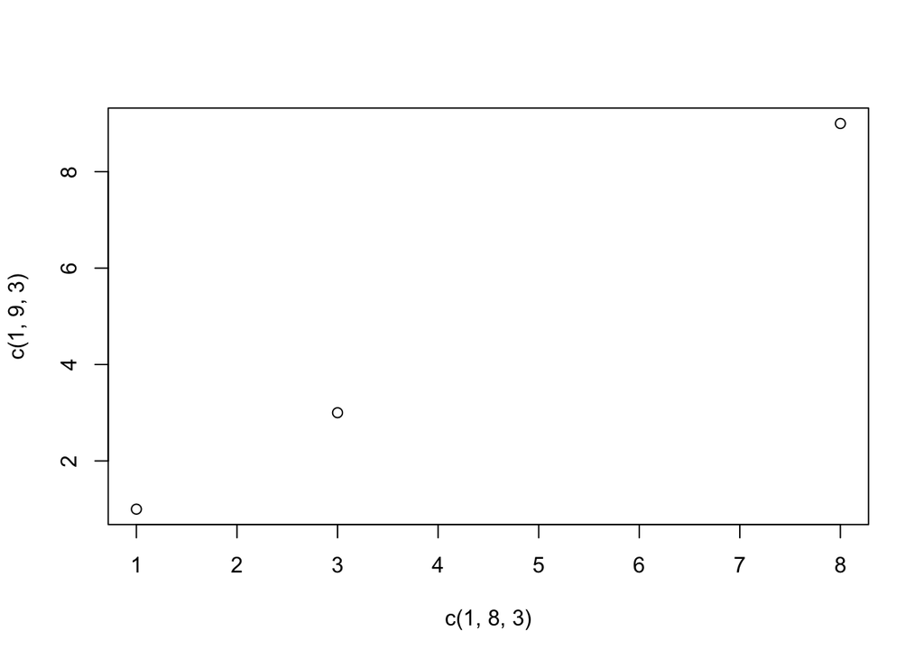